# final_R_reference

Julian Burgoff

2022-12-09

## Loading Data and Packages

```r
#Use library() to load previously installed packages

library(here)
library(palmerpenguins)

#Use require() to load previously installed packages

require(here)
require(palmerpenguins)

#Use read.csv() and here() to read data files

ginkgo = read.csv(here("data","ginkgo_data_2022.csv"))
```

## Data Structures

The c() function combines arguments of the same type (numeric, character) into a vector.

```r
## Create a vector of numbers:
num_vec  = c(1, 2, 3, 4, 5)

## Create a vector of characters:
char_vec = c("data", "analysis", "is cool")

## Type name of vector to print contents
num_vec
```

```
## [1] 1 2 3 4 5
```

```r
char_vec
```

```
## [1] "data"     "analysis" "is cool"
```

The length() function gets or sets the length of objects including vectors and lists in R.

```r
#Get length of vector
x <- c(1,2,4,8,10,13,15,19)
length(x)
```

```
## [1] 8
```

The matrix() function creates a matrix from a given set of values

```r
matrix_example <- matrix(c(5,10,15, 25,30,35), nrow = 2, ncol = 3, byrow = TRUE,
               dimnames = list(c("row_1", "row_2"), c("C_1", "C_2", "C_3")))
View(matrix_example)
```

The data.frame() function creates data frames which are collections of variables similar to matrices and lists. You can also turn matrices into data.frames using this function.

```r
data_frame <- data.frame(x1 = 1:10,
                    x2 = letters[1:10],
                    x3 = c(5, 10, 15, 20, 25,30,35,40,45,50),
                    x4 = "more data")
data_frame                             # print the data frame
```

```
##    x1 x2 x3        x4
## 1   1  a  5 more data
## 2   2  b 10 more data
## 3   3  c 15 more data
## 4   4  d 20 more data
## 5   5  e 25 more data
## 6   6  f 30 more data
## 7   7  g 35 more data
## 8   8  h 40 more data
## 9   9  i 45 more data
## 10 10  j 50 more data
```

```r
data_frame_from_matrix= data.frame(matrix_example)
data_frame_from_matrix         #print the converted data frame
```

```
##       C_1 C_2 C_3
## row_1   5  10  15
## row_2  25  30  35
```

The nrow() and ncol() functions return the number of rows and columns in a data.frame and the dim() function is used to get or set the dimensions of a data.frame

```r
# Investigate dimensions of previously loaded ginkgo data.frame
nrow(ginkgo) # number of rows
```

```
## [1] 220
```

```r
ncol(ginkgo) # number of columns
```

```
## [1] 6
```

```r
dim(ginkgo) # both number of rows and columns
```

```
## [1] 220   6
```

## Subsetting Data

$ is used to select columns by name within a data.frame

```r
# Select the max_width column in the ginkgo data frame and assign it to a variable

width_ginkgo= ginkgo$max_width
width_ginkgo
```

```
##   [1]  85  72  64  76  85  75  72  81  87  87  94  92  70  84  61 102  82  64
##  [19]  53  66  69  55  56  64  60  59  57  53  68  56  75  63  82  83  60  67
##  [37]  75  92 110  54  77  59  51 100  92  77  99  62  80  86  63  79  91  72
##  [55]  64  53  71  61  70  93  75  87  86  87  95  88  85  95  95  52  84  74
##  [73]  87  76  57  92  94  79  97  50 100  97  63  96  97  70  83  80  85 100
##  [91] 112 115  83 106  95  80 120  76  50  90  94  69  93  59  60 103  95  90
## [109]  80  90 106  98  73  89  65  83 116  90  86 104  92 103 100  91 102  99
## [127]  98 104  80  68  62  77  86  72  70  63  72  65  69  67  35  67  63  71
## [145]  77  60  70  69  55  72  84 106  61 114  95  86  60  78  86  91  79  95
## [163]  72 102  72 107  95  91  94  90  98  63  58  67  92  75  74  73  73  94
## [181]  76  86  78  74  89  77  80  71  69  81  39  60  50  47  52  61  56  45
## [199]  64  42 103  84 118 120 100 111 104  94  78  70  92  48  79  91 111  44
## [217] 117  93 101 145
```

[] is used to subset data.frames by position. Within the brackets, numbers to the left of the comma refer to position within rows and numbers to the right of the comma refer to position within columns

```r
#Select the first row in the ginkgo data.frame
ginkgo[1, ]
```

```
##   site_id seeds_present max_width max_depth notch_depth petiole_length
## 1     216         FALSE        85        59          12             91
```

```r
#Select the element in row 2 column 3 of the ginkgo data.frame
ginkgo[2,3]
```

```
## [1] 72
```

```r
#Select the 3rd column of the ginkgo data.frame. Without a comma, the subset returns a complete column
ginkgo[3]
```

```
##     max_width
## 1          85
## 2          72
## 3          64
## 4          76
## 5          85
## 6          75
## 7          72
## 8          81
## 9          87
## 10         87
## 11         94
## 12         92
## 13         70
## 14         84
```

[output cut: 206 more lines]

The subset() function is another way to subset a data.frame.

```r
# Subset penguins data frame to retrieve data on Adelie penguins from the species column
adelie_subset= subset(penguins, species %in% c("Adelie"))
```

## Numerical Data Exploration

The summary() function automatically calculates summary statistics of a vector or data.frame

```r
#summary of previously loaded penguins data

summary(penguins)
```

```
##       species          island    bill_length_mm  bill_depth_mm
##  Adelie   :152   Biscoe   :168   Min.   :32.10   Min.   :13.10
##  Chinstrap: 68   Dream    :124   1st Qu.:39.23   1st Qu.:15.60
##  Gentoo   :124   Torgersen: 52   Median :44.45   Median :17.30
##                                  Mean   :43.92   Mean   :17.15
##                                  3rd Qu.:48.50   3rd Qu.:18.70
##                                  Max.   :59.60   Max.   :21.50
##                                  NA's   :2       NA's   :2
##  flipper_length_mm  body_mass_g       sex           year
##  Min.   :172.0     Min.   :2700   female:165   Min.   :2007
##  1st Qu.:190.0     1st Qu.:3550   male  :168   1st Qu.:2007
##  Median :197.0     Median :4050   NA's  : 11   Median :2008
##  Mean   :200.9     Mean   :4202                Mean   :2008
##  3rd Qu.:213.0     3rd Qu.:4750                3rd Qu.:2009
##  Max.   :231.0     Max.   :6300                Max.   :2009
##  NA's   :2         NA's   :2
```

The mean() function gives the arithmetic mean of a vector

```r
# calculate the mean bill length of Adelie penguins from the previously subsetted data.frame

mean(adelie_subset$bill_length_mm, na.rm= TRUE)  #na.rm argument strips missing values
```

```
## [1] 38.79139
```

The sd() function calculates the standard deviation of an R object

```r
# Calculate standard deviation of bill lengths of Adelie penguins using subsetted data.frame

sd(adelie_subset$bill_length_mm, na.rm= TRUE)
```

```
## [1] 2.663405
```

```r
# na.rm argument omits missing values
```

## Graphical Data Exploration

The plot() function is used to create generic plots of objects in R

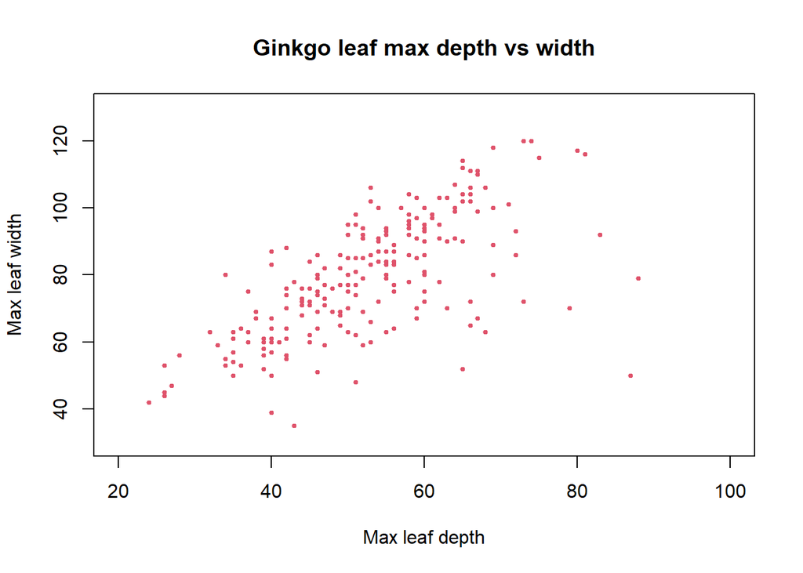

```r
# Scatterplot of max leaf depth and max leaf width from the ginkgo data
plot(ginkgo$max_depth, ginkgo$max_width,
     col=2,     #col changes point color
     pch=19,    #pch changes character type
     cex= 0.5,   #cex changes point size
     main="Ginkgo leaf max depth vs width", #main provides a title for the plot
     xlab= "Max leaf depth", #xlab provides a label for the x axis
     ylab= "Max leaf width", #ylab provides a label for the y axis
     xlim= c(20,100), #xlim sets x range
     ylim = c(30,130) #ylim sets y range
)
```

The hist() function computes a histogram from given data values

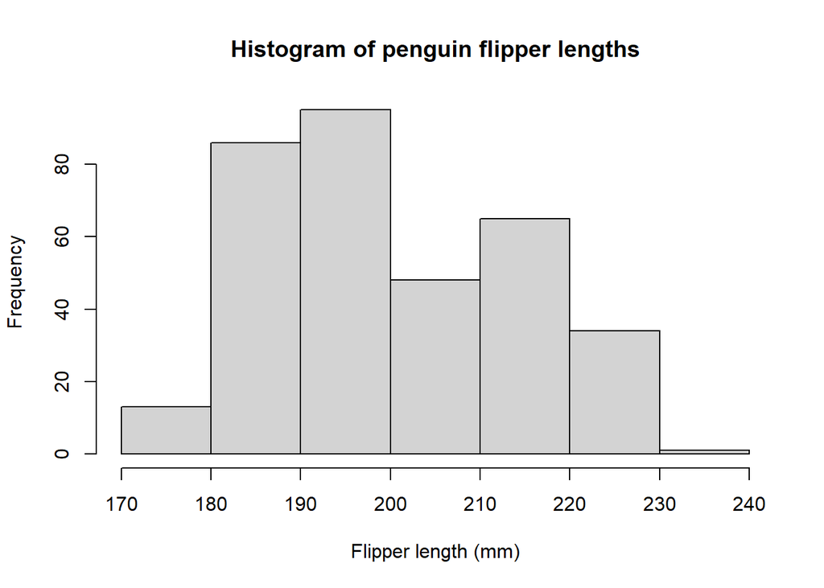

```r
#Create a histogram of penguin flipper lengths using the previously loaded penguins data
hist(penguins$flipper_length_mm, main= "Histogram of penguin flipper lengths", xlab= "Flipper length (mm)",
     breaks= 8, #breaks argument specifies cell boundaries
)
```

The boxplot() function creates box and whisker plots of grouped values

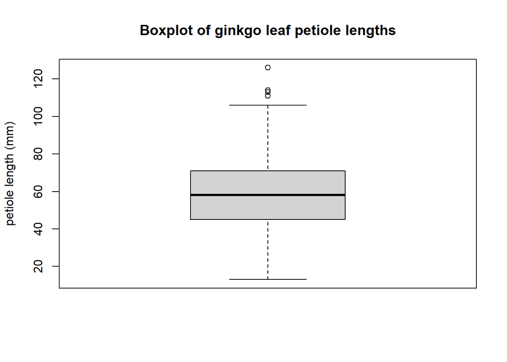

```r
#boxplot of petiole lengths using ginkgo data

boxplot(ginkgo$petiole_length, ylab= "petiole length (mm)", main= "Boxplot of ginkgo leaf petiole lengths")
```

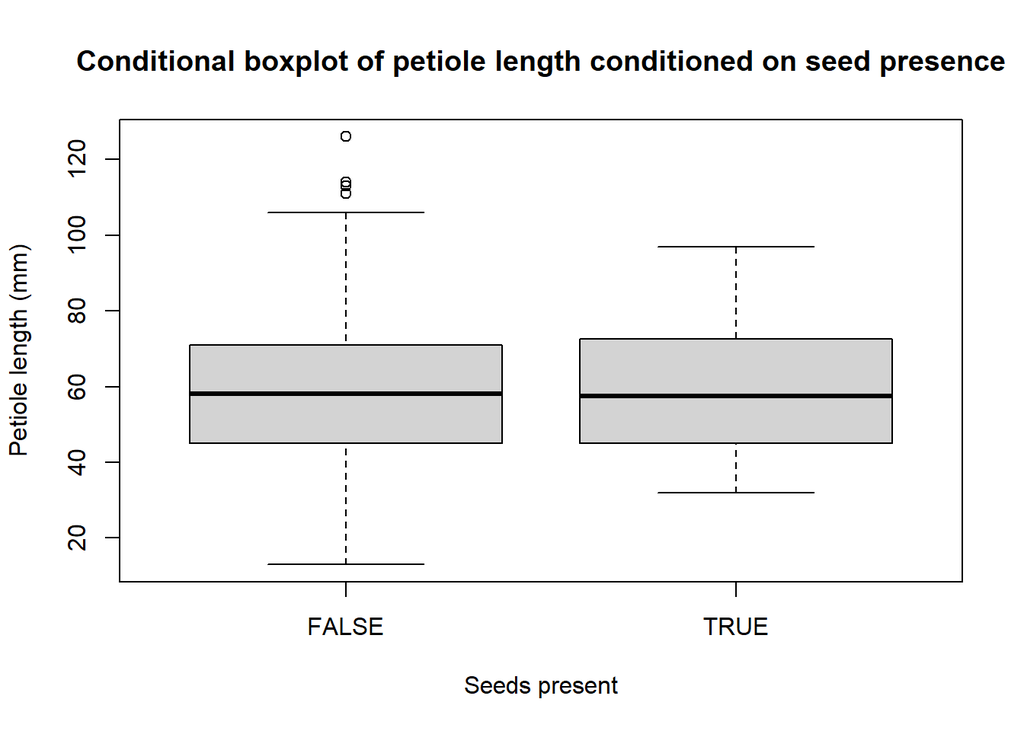

```r
#conditional boxplot of petiole length conditioned on the seeds_present column of the ginkgo data

boxplot(ginkgo$petiole_length~ginkgo$seeds_present, xlab= "Seeds present", ylab= "Petiole length (mm)", main= "Conditional boxplot of petiole length conditioned on seed presence")
```

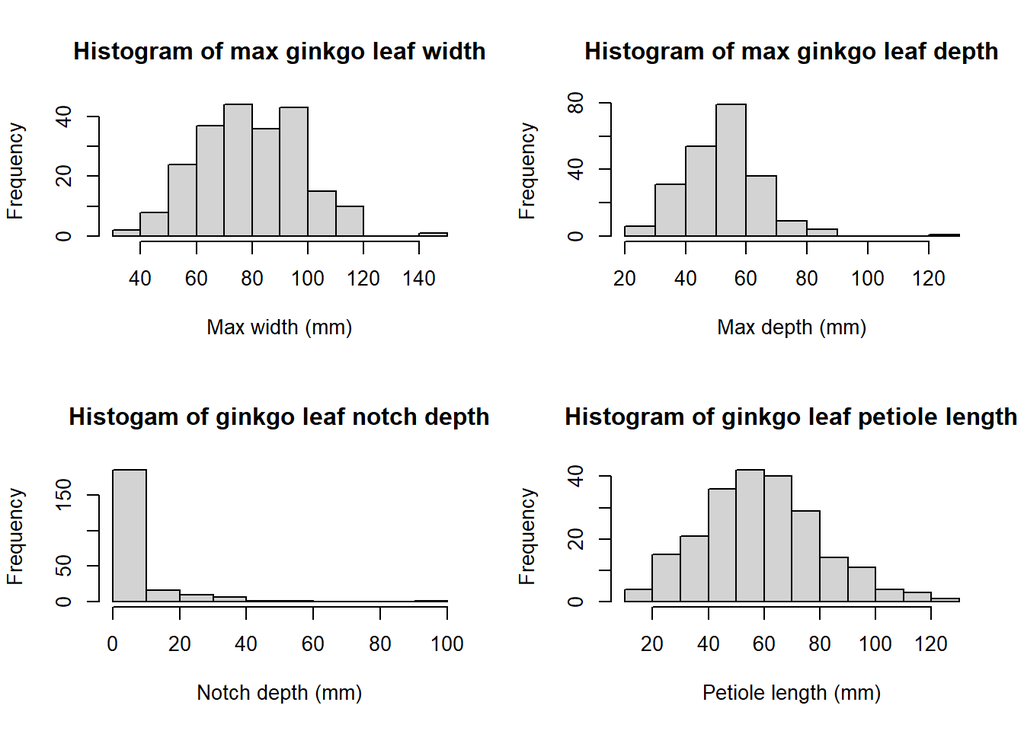

```r
# 4 panel figure of histograms
par(mfrow= c(2,2)) # creates 2X2 matrix of plots
hist(ginkgo$max_width, xlab= "Max width (mm)", main= "Histogram of max ginkgo leaf width")

hist(ginkgo$max_depth, xlab= "Max depth (mm)", main= "Histogram of max ginkgo leaf depth")

hist(ginkgo$notch_depth, xlab= "Notch depth (mm)", main= "Histogam of ginkgo leaf notch depth")

hist(ginkgo$petiole_length, xlab= "Petiole length (mm)", main= "Histogram of ginkgo leaf petiole length")
```

## Distribution Functions

dnorm() function gives the value of the probability density function given a random variable, population mean, and population standard deviation

```r
#Find the value of the normal distribution pdf at x=2, mean=0, sd=1
dnorm(x=2,mean=0,sd=1)
```

```
## [1] 0.05399097
```

The pnorm() function gives the value of the cumulative density function of the normal distribution given a random variable, population mean, and population standard deviation

```r
pnorm(50, mean= 48, sd=2, lower.tail= FALSE #FALSE lower.tail because we want to know the percentage of fish longer than 50mm
)
```

```
## [1] 0.1586553
```

```r
#15.9 percent of fish are longer than 50 mm in this pond
```

The qnorm() function gives the value of the inverse cumulitive density function given a random variable, the population mean, and population standard deviation

```r
qnorm(0.75, mean=0, sd=1)
```

```
## [1] 0.6744898
```

The dbinom() calculates the probability binomial mass function for a given set of values, number of trials, and probability of success

```r
#calculate the binomial probability mass function for x= 1:5 and a probability of success in each trial of 0.5

dbinom(x=1:5, size= 10, prob=0.5)
```

```
## [1] 0.009765625 0.043945312 0.117187500 0.205078125 0.246093750
```

The pbinom() function calculates the probability of a variable (x) following a binomial distribution with values less than or equal to x

```r
#Calculate the probability of success occurring less than 5 times if the number of trials is 20 and the probability of success is 0.2
pbinom(5, size=20, prob= 0.2)
```

```
## [1] 0.8042078
```

```r
#probability is 80%
```

Given a set of probabilities, use the qbinom() function to get the corresponding binomial quantile

```r
#Get the binomial quantile for the probability 0.5 if n= 10 and p=0.8
qbinom(p=0.5, size= 10, prob=0.8) #8
```

```
## [1] 8
```